# El impacto de la pandemia en el uso de las billeteras digitales en Lima Metropolitana, mayo de 2023

## **1. Introducción**

Durante la pandemia del COVID-19, muchos ciudadanos consideraron riesgoso el contacto con otras personas u objetos, debido al temor de ser contagiados. En particular, la acción de dar o recibir dinero se percibía como peligrosa para la salud, ya que no se sabía si la otra persona estaba contagiada o no. A través de este intercambio de dinero, existía la posibilidad de contagio hacia el receptor. Como resultado, surgió la necesidad de encontrar una forma de realizar pagos sin tener que utilizar efectivo, además de ser de fácil uso y accesible para toda la población. Así es como se popularizó el uso de las billeteras digitales, ofreciendo una alternativa acorde a las necesidades que ameritaba el estado de emergencia.

Debido a esta situación, se ha generado la importancia de comprender el impacto de la pandemia en el uso de las billeteras digitales. Su adopción continúa en aumento y se decidió realizar un estudio en Lima Metropolitana para obtener una mayor variedad de distritos y recopilar diversas opiniones al respecto.

### 1.1. Relevancia

Este estudio nos permitirá analizar las razones de por qué las billeteras digitales se volvieron de uso cotidiano en la población de Lima Metropolitana, puesto que las billeteras digitales ahora son parte de nuestro día a día y se utilizan tanto para transferencias como para pagos de servicios. De esta manera, se podrá saber más sobre ello y ver como ha ido evolucionando en el lapso de tiempo de la pandemia.

### 1.2. Objetivos

- Determinar las razones de por qué las personas no usaban las billeteras digitales antes de la pandemia en Lima Metropolitana, mayo de 2023.
- Identificar las razones del cambio a las billeteras digitales durante o tras la pandemia en Lima Metropolitana, mayo de 2023.
- Evaluar los factores predominantes que influyen en la permanencia en el uso de billeteras virtuales tras el término de la pandemia en Lima Metropolitana, mayo de 2023.

### 1.3. Contexto

A inicios de 2020 empezó una pandemia mundial, aislando a la población entera en sus hogares y evitando, en la medida de lo posible, el contacto entre las personas. Esta pandemia empezó a terminar a finales de 2022 y con ello empezó la popularidad de las billeteras digitales que ganaron terreno como medio de pago más usado con respecto al efectivo debido a que este se quedaba obsoleto frente a lo que las billeteras digitales ofrecían a la población.

## **2. Análisis descriptivo**

### 2.1. Tiempo de uso de las billeteras digitales

#### 2.1.1. Diagrama de densidad

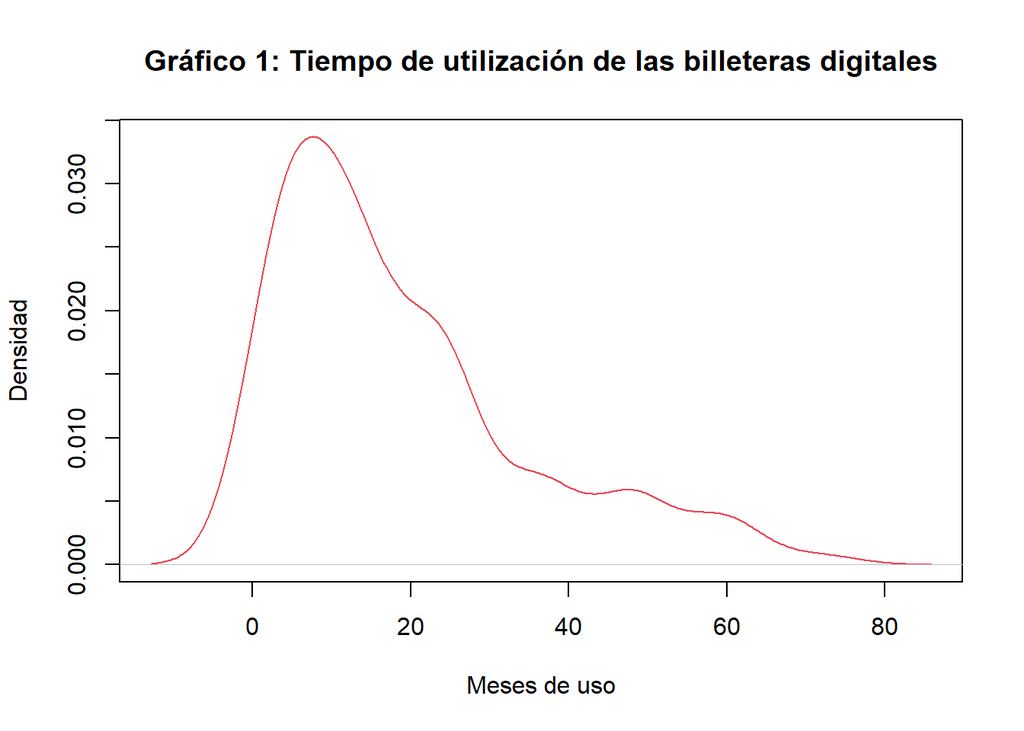

**Análisis de la gráfica 1: Una gran mayoría de los encuestados que usan este método de pago tienen un tiempo de uso menor a 30 meses, aproximadamente. En otras palabras, comenzaron a usarlo a finales de la pandemia. Además se puede observar una distribución sesgada hacía la derecha.**

#### 2.1.2. Descriptores de posición Y de dispersión

```r
summary(DD$`Tiempo de utilización de la billetera digital`)
```

```
##    Min. 1st Qu.  Median    Mean 3rd Qu.    Max.    NA's
##    1.00    6.00   12.00   18.96   24.00   72.00      48
```

```r
sprintf("La moda es: %d", V1)
```

```
## [1] "La moda es: 24"
```

```r
sprintf("La desviación estándar es: %f", V2)
```

```
## [1] "La desviación estándar es: 16.290000"
```

```r
sprintf("El coeficiente de variación es: %f", V3)
```

```
## [1] "El coeficiente de variación es: 0.860000"
```

#### 2.1.3. Boxplot

Debido a que el coeficiente de variación es alto, la mediana es la que mejor representaría a la población y para un mejor análisis de la variable se utilizaría un boxplot.

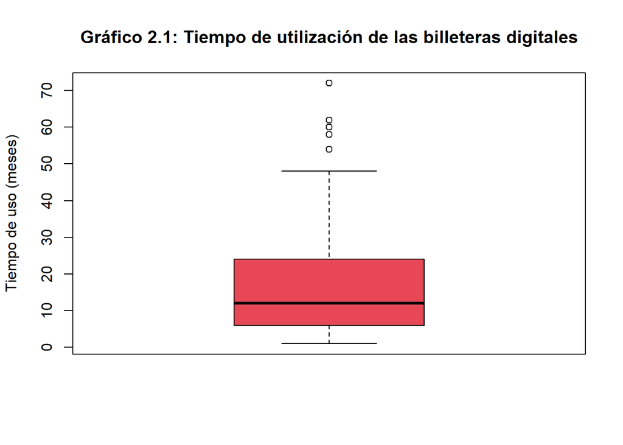

Como la variable posee valores extremos que nos impiden observar y analizar detalladamente el boxplot, entonces se procederá a eliminar aquellos datos extremos del gráfico.

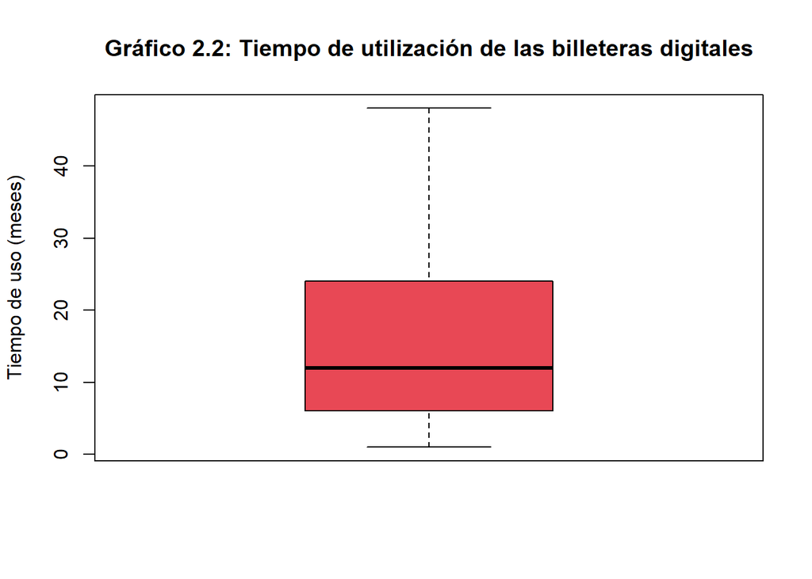

### 2.2. Comparación entre el conocimiento de la existencia de las billeteras digitales y su utilización (prepandemia)

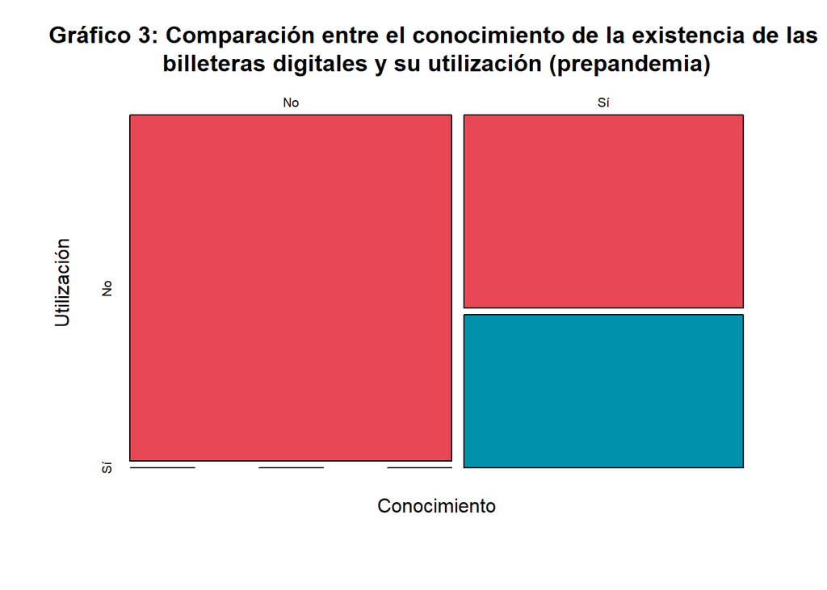

**Analisis de la gráfica 3: La falta de conocimiento sobre las billeteras digitales fue el factor clave que impedía su adopción en el pasado, antes de que la pandemia tuviera lugar.**

### 2.3. Contabilización de la principal razón de la no utilización de billeteras digitales en usuarios que conocían de la existencia de este método de pago (prepandemia)

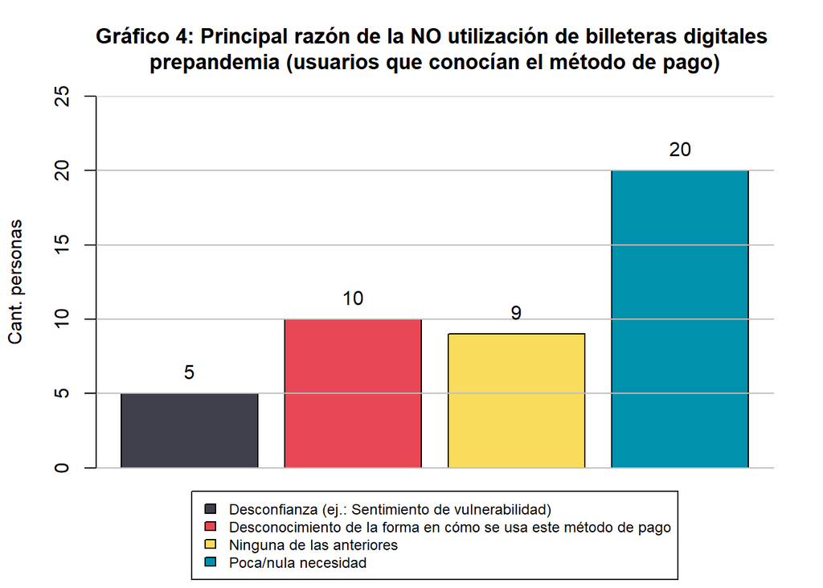

**Análisis de la gráfica 4: La poca/nula necesidad de las personas para el uso de esta billetera digital prepandemia es la principal razón por la que este medio de pago no era tomado en cuenta para los que no usaban este medio de pago**

### 2.4. Contabilización de los usuarios de billeteras digitales a partir de sus razones iniciales de uso

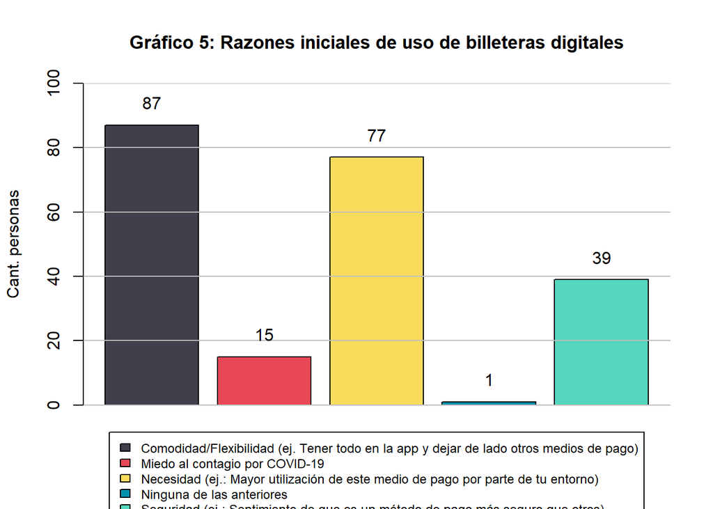

**Análisis de la gráfica 5: La comodidad y necesidad se presentan como los factores más importantes al momento de empezar a usar las billeteras digitales, además a pesar de la existencia del COVID-19 se puede observar una limitada cantidad de personas que eligieron esta opción como una de las razones por la cual empezaron a usar este medio de pago.**

### 2.5. Factores predominantes que influyen en la permanencia en el uso de billeteras virtuales tras el término de la pandemia en Lima Metropolitana

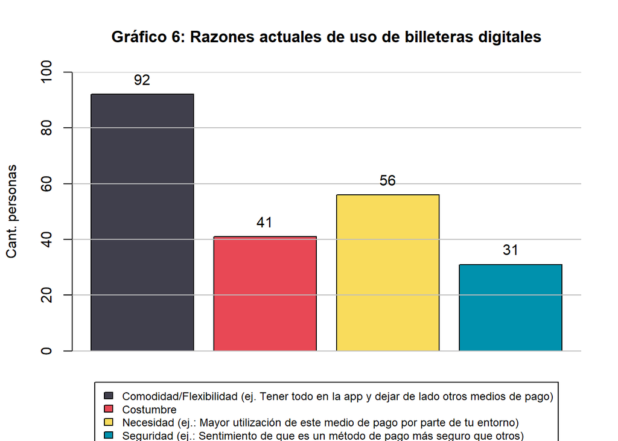

- De los gráficos 5 y 6, se puede concluir que el uso de las billeteras digitales se debe a una cuestión de comodidad para el usuario y facilidad para pagar debido a una necesidad de que el entorno del usuario también use en su mayoría las billeteras digitales.

### 2.6. Comparación entre la comodidad de los encuestados con su método principal de pago y su método principal de pago

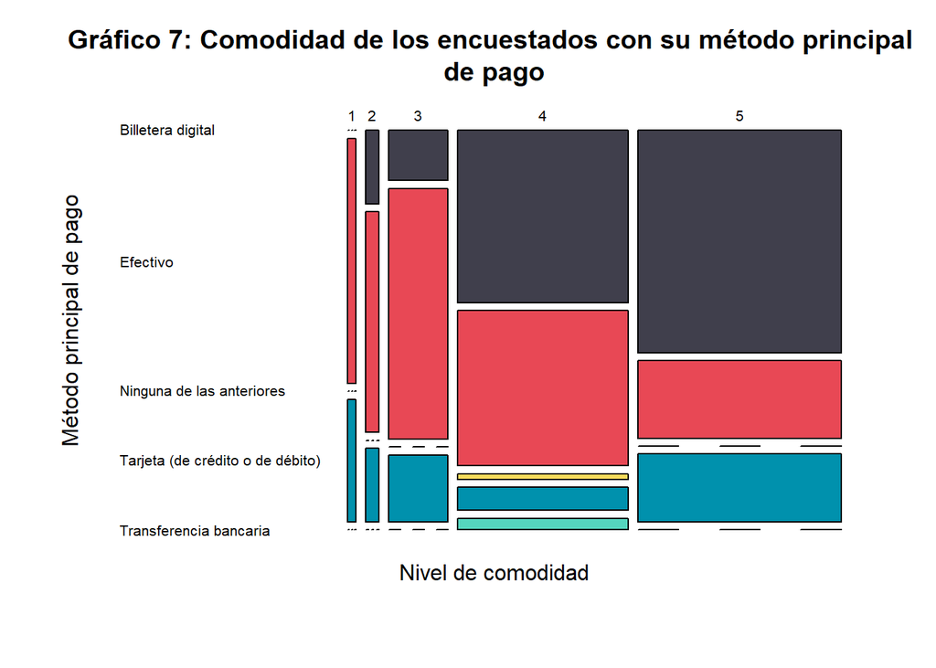

**Análisis: La billetera digital en su mayoría ofrece un nivel de comodidad alto (4-5) en comparación de otros métodos de pago, confirmando que para los usuarios de billeteras digitales la comodidad es la principal razón de su uso. El efectivo por su parte presenta una mayor variación con respecto al nivel de comodidad, se observa incremento de usuarios a los cuales les parece que este medio de pago ofrece un nivel de comodidad bajo (1-3).**

### 2.7. Comparación del gasto prepandemia y postpandemia con la billeteras digital más usadas para los usuarios que no las usaban prepandemia

#### 2.7.1. Diagrama de dispersión

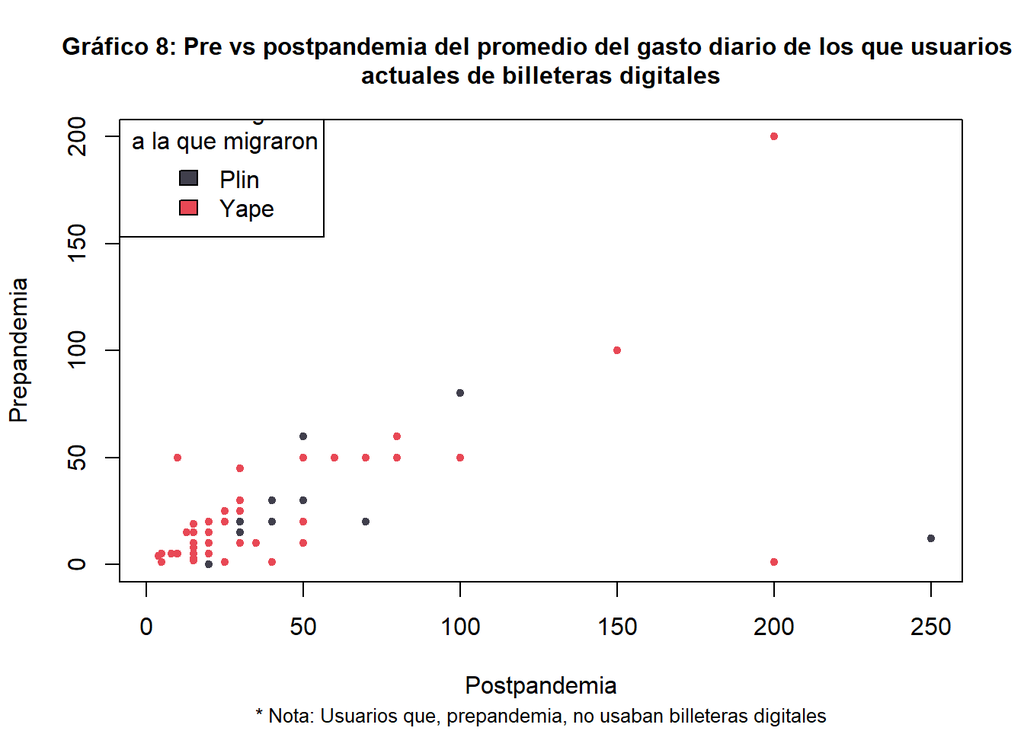

**Análisis: La mayoría de usuarios que han migrado durante o tras la pandemia manejan cantidades de dinero baja con las billeteras digitales (hasta S/50) y usan aplicativos que son conocidos para transferencias de ese tipo (Yape y Plin). Además, se refleja cierto aumento en la cantidad gastada postpandemia con respecto a la prepandemia.**

#### 2.7.2. Relación lineal

```r
sprintf("La covarianza de ambas variables para los usuarios de Plin es: %f", corrP1)
```

```
## [1] "La covarianza de ambas variables para los usuarios de Plin es: 0.529493"
```

```r
sprintf("La covarianza de ambas variables para los usuarios de Yape es: %f", corrY1)
```

```
## [1] "La covarianza de ambas variables para los usuarios de Yape es: 0.768296"
```

**Análisis: Tanto para los usuarios de Yape como de Plin actuales que no usaban las billeteras digitales prepandemia se puede afirmar que el gasto postpandemia y gasto prepandemia están relacionados directamente, es decir, para un gasto mayor postpandemia se va a encontrar un gasto mayor prepandemia y viceversa. Además, los usuarios de Yape son los que tienen una mayor tendencia en esta relación que los usuarios de Plin.**

- Como el gasto postpandemia es mayor que el prepandemia, se puede afirmar que en su mayoría existirá que hay un mayor gasto postpandemia que prepandemia, por lo que, las billeteras digitales implican un gasto diario mayor.

### 2.8. Comparación del gasto prepandemia y postpandemia con la billeteras digital más usadas para los usuarios que sí las usaban prepandemia

#### 2.8.1. Diagrama de dispersión

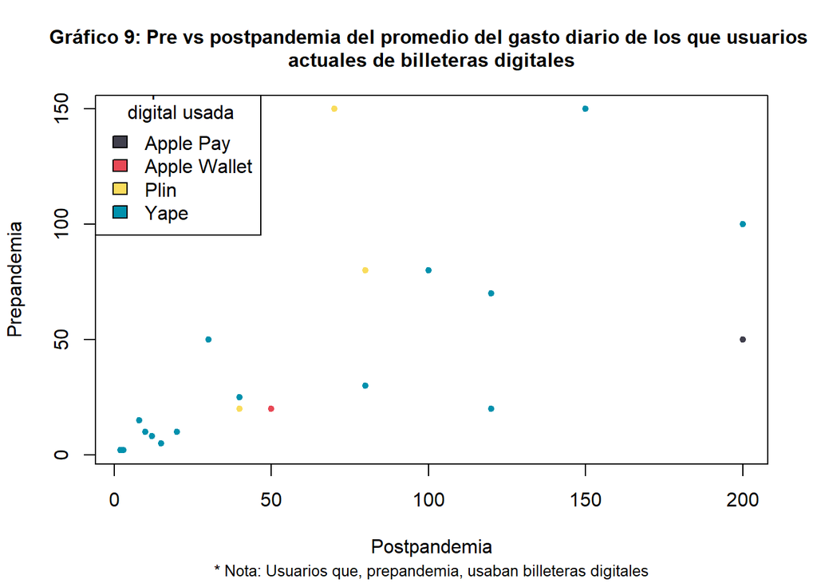

- De las gráficas 8 y 9, se puede concluir que el gasto de dinero postpandemia tuvo un incremento con respecto a la prepandemia para los usuarios que actualmente usan billeteras digitales tanto para los que no las usaban prepandemia como para los que las usaban prepandemia.

#### 2.8.2. Relación lineal

Debido a que para las billeteras digitales Apple Wallet y Apple Pay solo constan de 1 usuario y los usuarios de Plin son solo 3, se va a realizar el análisis de relación lineal con los usuarios de Yape y con todas las billeteras digitales en conjunto.

```r
sprintf("La covarianza de ambas variables para los usuarios de Yape es: %f", corrY2)
```

```
## [1] "La covarianza de ambas variables para los usuarios de Yape es: 0.824089"
```

```r
sprintf("La covarianza de ambas variables para todos los usuarios: %f", corrV)
```

```
## [1] "La covarianza de ambas variables para todos los usuarios: 0.632445"
```

**Análisis: Tanto para los usuarios de Yape como de billeteras digitales en general que usaban las billeteras digitales prepandemia se puede afirmar que el gasto postpandemia y gasto prepandemia están relacionados directamente, es decir, para un gasto mayor postpandemia se va a encontrar un gasto mayor prepandemia y viceversa. Además, los usuarios de Yape son los que tienen una relación más directa.**

- Como el gasto postpandemia es mayor que el prepandemia, se puede afirmar que en su mayoría existirá que hay un mayor gasto postpandemia que prepandemia, por lo que, la pandemia tuvo un efecto de mayor consumo en los usuarios de billeteras digitales y por consecuencia un mayor uso de estas para los que anteriormente usaban las billeteras digitales.

## **3. Análisis probabilístico**

### 3.1. Probabilidad empírica

**Variables:**

- *Principal razón de la utilización de las billeteras digitales antes de la pandemia*
- *Nivel de creencia de la rapidez de las billeteras digitales*

**Experimento 1: Seleccionar una persona del estudio “El impacto de la pandemia en el uso de las billeteras digitales en Lima Metropolitana” y observar la principal razón por la cual la empezó a utilizar**

0. Espacio muestral

$$\Omega_1 = \{Accesibilidad, comodidad,
necesidad, seguridad\}$$

**Evento 1**: Seleccionar una persona del estudio “El impacto de la pandemia en el uso de las billeteras digitales en Lima Metropolitana” que tiene como razón principal por la cual empezó a utilizar la billetera digital la necesidad.

1. ¿Cuál es la probabilidad que la razón principal sea la necesidad?
   $$P(Necesidad) = \frac{Cant. \hspace{0.1cm}
   necesidad}{Total}$$

```r
round(sum(filter(DF1, DF1$Var1 == "Necesidad (ej.: Este medio era muy usado en su entorno)")[2])/Total1, 2)
```

```
## [1] 0.14
```

**Evento 2**: Seleccionar una persona del estudio “El impacto de la pandemia en el uso de las billeteras digitales en Lima Metropolitana” que tiene como razón principal por la cual empezó a utilizar la billetera digital la comodidad.

2. ¿Cuál es la probabilidad que el motivo principal haya sido la comodidad?
   $$P(Comodidad) = \frac{Cant.
   \hspace{0.1cm} comodidad}{Total}$$

```r
round(sum(filter(DF1, DF1$Var1 == "Comodidad (ej.: Integridad con otros medios de pago)")[2])/Total1, 2)
```

```
## [1] 0.43
```

**Evento 3**: Seleccionar una persona del estudio “El impacto de la pandemia en el uso de las billeteras digitales en Lima Metropolitana” que tiene como razón principal por la cual empezó a utilizar la billetera digital la accesibilidad

3. Probabilidad de que una persona haya tenido como causa primaria de uso la accesibilidad.
   $$P(Accesibilidad) =
   \frac{Cant. \hspace{0.1cm} accesibilidad}{Total}$$

```r
round(sum(filter(DF1, DF1$Var1 == "Accesibilidad (ej.: Realizar transferencias desde el teléfono)")[2])/Total1, 2)
```

```
## [1] 0.29
```

**Evento 4**: Seleccionar una persona del estudio “El impacto de la pandemia en el uso de las billeteras digitales en Lima Metropolitana” que tiene como razón principal por la cual empezó a utilizar la billetera digital la seguridad

4. Probabilidad de que la seguridad haya sido la razón principal por la que una persona haya comenzado a usar billeteras digitales.
   $$P(Seguridad) = \frac{Cant. \hspace{0.1cm}
   seguridad}{Total}$$

```r
round(sum(filter(DF1, DF1$Var1 == "Seguridad (ej.: Menos riesgo de robo)")[2])/Total1, 2)
```

```
## [1] 0.14
```

- Conclusión: Es más probable que una persona use este método de pago por comodidad principalmente, más allá de otros factores de importancia como la seguridad

**Experimento 2: Seleccionar una persona del estudio “El impacto de la pandemia en el uso de las billeteras digitales en Lima Metropolitana” y observar su nivel de creencia de la rapidez de las billeteras digitales**

0. Espacio muestral:

$$\Omega_2 = \{1, 2, 3, 4,
5\}$$

**Evento 1**: Seleccionar una persona del estudio “El impacto de la pandemia en el uso de las billeteras digitales en Lima Metropolitana” que presenta un nivel comodidad de 5 en su método principal de pago.

1. Probabilidad de que las personas crean que la rapidez de las billeteras digitales son un 5/5.
   $$P(5
   \hspace{0.1cm} de \hspace{0.1cm} 5) = \frac{Cant. \hspace{0.1cm} de
   \hspace{0.1cm} 5 \hspace{0.1cm}}{Total}$$

```r
round(sum(filter(DF2, DF2$Var1 == "5")[2])/Total2, 2)
```

```
## [1] 0.44
```

**Evento 2**: Seleccionar una persona del estudio “El impacto de la pandemia en el uso de las billeteras digitales en Lima Metropolitana” que presenta un nivel comodidad de 4 en su método principal de pago.

2. Probabilidad de que las personas crean que la rapidez de las billeteras digitales son un 4/5.
   $$P(4
   \hspace{0.1cm} de \hspace{0.1cm} 5) = \frac{Cant. \hspace{0.1cm} de
   \hspace{0.1cm} 4 \hspace{0.1cm}}{Total}$$

```r
round(sum(filter(DF2, DF2$Var1 == "4")[2])/Total2, 2)
```

```
## [1] 0.29
```

**Evento 3**: Seleccionar una persona del estudio “El impacto de la pandemia en el uso de las billeteras digitales en Lima Metropolitana” que presenta un nivel comodidad de 3 en su método principal de pago.

3. Probabilidad de que las personas crean que la rapidez de las billeteras digitales son un 3/5.
   $$P(3
   \hspace{0.1cm} de \hspace{0.1cm} 5) = \frac{Cant. \hspace{0.1cm} de
   \hspace{0.1cm} 3 \hspace{0.1cm}}{Total}$$

```r
round(sum(filter(DF2, DF2$Var1 == "3")[2])/Total2, 2)
```

```
## [1] 0.19
```

**Evento 4**: Seleccionar una persona del estudio “El impacto de la pandemia en el uso de las billeteras digitales en Lima Metropolitana” que presenta un nivel comodidad de 2 en su método principal de pago.

4. Probabilidad de que las personas crean que la rapidez de las billeteras digitales son un 2/5.
   $$P(2
   \hspace{0.1cm} de \hspace{0.1cm} 5) = \frac{Cant. \hspace{0.1cm} de
   \hspace{0.1cm} 2 \hspace{0.1cm}}{Total}$$

```r
round(sum(filter(DF2, DF2$Var1 == "2")[2])/Total2, 2)
```

```
## [1] 0.06
```

**Evento 5**: Seleccionar una persona del estudio “El impacto de la pandemia en el uso de las billeteras digitales en Lima Metropolitana” que presenta un nivel comodidad de 1 en su método principal de pago.

5. Probabilidad de que las personas crean que la rapidez de las billeteras digitales son un 1/5.
   $$P(1
   \hspace{0.1cm} de \hspace{0.1cm} 5) = \frac{Cant. \hspace{0.1cm} de
   \hspace{0.1cm} 1 \hspace{0.1cm}}{Total}$$

```r
round(sum(filter(DF2, DF2$Var1 == "1")[2])/Total2, 2)
```

```
## [1] 0.01
```

- Conclusión: Más del 70% creen que las billeteras digitales tienen un alto nivel de rapidez. Esto, de cierta manera, da lugar a que hay un condicionamiento para bien de estas sobre este tipo de método de pago.

### 3.2. Probabilidad condicional

#### 3.2.1 Eventos independientes

**Comprobación de la independencia**

```r
# Tabla
DF1
```

| Conocimiento de la existencia de las billeteras digitales antes de la pandemia | Gasto diario mayor a 100 soles | Gasto menor e igual a 100 soles |
| --- | --- | --- |
| No | 14 | 77 |
| Sí | 13 | 66 |

```r
# Cantidades para cada caso
nA <- 77 + 66
nB <- 13 + 66
nB2 <- 14+ 77
nAB2 <- 77
nAB <- 66
nT <- 170
```

**Evento A**: Seleccionar una persona del estudio “El impacto de la pandemia en el uso de las billeteras digitales en Lima Metropolitana” que tenga un gasto diario menos a 100 soles.

**Evento B**: Seleccionar una persona del estudio “El impacto de la pandemia en el uso de las billeteras digitales en Lima Metropolitana” que supiera de la existencia de las billeteras digitales prepandemia.

$$\mathbb{P}(A \cap B) =
\mathbb{P}(A)*\mathbb{P}(B)$$

```r
# P(A∩B)
round(nAB/nT,2)
```

```
## [1] 0.39
```

```r
# P(A)*P(B)
round(nA*nB/(nT*nT),2)
```

```
## [1] 0.39
```

$$\mathbb{P}(A | B) = \mathbb{P}(A)$$

```r
# P(A|B)
round(nAB/nB,2)
```

```
## [1] 0.84
```

```r
# P(A)
round(nA/nT,2)
```

```
## [1] 0.84
```

$$P(A|B) = \frac{ P(A \cap
B)}{P(B)}$$

```r
# P(A|B)
round(nAB/nB,2)
```

```
## [1] 0.84
```

```r
# P(A∩B)/P(B)
round((nAB/nT)/(nB/nT),2)
```

```
## [1] 0.84
```

Teorema de Bayes
$$P(A|B)=\frac{ P(B|A) *
P(A)}{P(B)}$$

```r
PBA <- nAB/nA
PA <- nA/nT
PB <- nB/nT
# P(A|B)
round(nAB/nB,2)
```

```
## [1] 0.84
```

```r
# P(B|A)*P(A)/P(B)
round(PBA*PA/PB,2)
```

```
## [1] 0.84
```

Probabilidad total

$$P(A)=P(A|B_1)*P(B_1)+P(A|B_2)*P(B_2)+...P(A|B_k)*P(B_k)$$

```r
PAB1 <- nAB/nB
PAB2 <- nAB2/nB2
PB2 <- nB2/nT
# P(A)
round(PA,2)
```

```
## [1] 0.84
```

```r
# P(A|B1)*P(B1)+P(A|B2)*P(B2)
round(PAB1*PB + PAB2*PB2, 2)
```

```
## [1] 0.84
```

#### 3.2.2 Eventos dependientes

```r
# Tabla
table(DF3)
```

```
##                                   DF..Utilización.de.las.billeteras.digitales.antes.de.la.pandemia.
## DF..Método.principal.de.pago.      No Sí
##   Billetera digital                17 25
##   Efectivo                         21  4
##   Ninguna de las anteriores         0  0
##   Tarjeta (de crédito o de débito)  5  6
##   Transferencia bancaria            1  0
```

```r
# Cantidades para cada caso
nA <- 25 + 4 + 0 + 6 + 0
nBi <- 17 + 25
nE <- 21 + 4
nNA <- 0 + 0
nT <- 5 + 6
nTB <- 1 + 0
nABI <- 25
nAE <- 4
nANA <- 0
nAT <- 6
nATB <- 0
nTotal <- 17+25+21+4+5+6+1
```

**Evento A**: Seleccionar una persona del “El impacto de la pandemia en el uso de las billeteras digitales en Lima Metropolitana” que utilizaba las billeteras digitales prepandemia.

**Evento B**: Seleccionar una persona del estudio “El impacto de la pandemia en el uso de las billeteras digitales en Lima Metropolitana” que actualmente use las billeteras digitales como medio de pago.

$$\mathbb{P}(A \cap B) \space
!= \mathbb{P}(A)*\mathbb{P}(B)$$

```r
#P(A∩B)
round(nABI/nTotal,2)
```

```
## [1] 0.32
```

```r
#P(A)*P(B)
round(nA*nBi/(nTotal*nTotal),2)
```

```
## [1] 0.24
```

$$\mathbb{P}(A | B) \space !=
\mathbb{P}(A)$$

```r
#P(A|B)
round(nABI/nBi,2)
```

```
## [1] 0.6
```

```r
#P(A)
round(nA/nTotal,2)
```

```
## [1] 0.44
```

Probabilidad condicional: La probabilidad de que un estudiante del estudio utilizase billeteras digitales prepandemia dado que actualmente las use.
$$P(A|B) = \frac{ P(A \cap
B)}{P(B)}$$

```r
#P(A|B)
round(nABI/nBi,2)
```

```
## [1] 0.6
```

```r
#P(A∩B)/P(B)
round((nABI/nTotal)/(nBi/nTotal),2)
```

```
## [1] 0.6
```

Teorema de Bayes
$$P(A|B)=\frac{ P(B|A) *
P(A)}{P(B)}$$

```r
PBA <- nABI/nA
PA <- nA/nTotal
PB <- nBi/nTotal
#P(A|B)
round(nABI/nBi,2)
```

```
## [1] 0.6
```

```r
#P(B|A)*P(A)/P(B)
round(PBA*PA/PB,2)
```

```
## [1] 0.6
```

Probabilidad total

$$P(A)=P(A|B_1)*P(B_1)+P(A|B_2)*P(B_2)+...P(A|B_k)*P(B_k)$$

```r
PAB1 <- nABI/nBi
PAB2 <- nAE/nE
PAB3 <- 0
PAB4 <- nAT/nT
PAB5 <- nATB/nTB
PB1 <- nBi/nTotal
PB2 <- nE/nTotal
PB3 <- nNA/nTotal
PB4 <- nT/nTotal
PB5 <- nTB/nTotal
#P(A)
round(PA,2)
```

```
## [1] 0.44
```

```r
#P(A|B1)*P(B1)+P(A|B2)*P(B2)
round(PAB1*PB1 + PAB2*PB2 + PAB3*PB3 + PAB4*PB4 + PAB5*PB5, 2)
```

```
## [1] 0.44
```